# PCFL 2021: Week 5 wrap-up

A reminder at the outset: bye weeks start *THIS WEEK*!! Check your lineups and plan ahead.

### Last week’s games

| Away | Away points | Home | Home points |
| --- | --- | --- | --- |
| Captain Clairvoyant | 147.34 | Southern Sharks | 114.02 |
| Georgia Peanuts | 158.97 | The Sophomores TSoph | 132.16 |
| The G.O.A.T. | 98.48 | Pigskin on the Gridiron | 107.18 |
| KC Gophers | 91.78 | Middle Earth Hangry Hobbits | 125.10 |
| Athens Team Sasquatch | 149.80 | Jumpin’ Jaheims | 111.68 |

And then there were none. Our last undefeated, The Sophomores, fell to my mighty Peanuts this week, despite putting up a respectable 132 points. Any given Sunday, y’all.

In other action, Brian’ Captain Clairvoyant rebounded for a win this week against Sarah’s Southern Sharks. Robby’s Team Sasquatch clobbered Evan’s Jumpin Jaheims, and Scott’s Hobbits dug out the Gophers. Lastly, in a matchup for the Pages, The Pigskin on the Gridiron best the GOAT.

#### Best performing players

Here’s last week’s **10 best performing players.**

| Player | Points | Team |
| --- | --- | --- |
| Justin Herbert | 42.82 | Georgia Peanuts |
| Lamar Jackson | 41.88 | Middle Earth Hangry Hobbits |
| Tom Brady | 37.74 | Captain Clairvoyant |
| Josh Allen | 36.50 | Athens Team Sasquatch |
| Mark Andrews | 36.20 | Georgia Peanuts |
| Mike Williams | 34.50 | KC Gophers |
| Davante Adams | 32.10 | Georgia Peanuts |
| Jonathan Taylor | 31.40 | Captain Clairvoyant |
| Derrick Henry | 31.00 | Middle Earth Hangry Hobbits |
| Austin Ekeler | 30.40 | The G.O.A.T. |

#### Best addition and top bench

There were 13 players added last week. Which was the **best new addition**?

| Date added | Name | Points | Team |
| --- | --- | --- | --- |
| 2021-10-06 | Dawson Knox | 20.20 | Georgia Peanuts |
| 2021-10-07 | Samaje Perine | 16.30 | Georgia Peanuts |
| 2021-10-06 | Damien Williams | 15.40 | Athens Team Sasquatch |
| 2021-10-08 | Michael Carter | 13.30 | Athens Team Sasquatch |
| 2021-10-06 | Dalton Schultz | 10.90 | Southern Sharks |
| 2021-10-06 | Hunter Renfrow | 9.05 | Georgia Peanuts |
| 2021-10-06 | Cowboys D/ST | 9.00 | Southern Sharks |
| 2021-10-08 | Alex Collins | 8.20 | Athens Team Sasquatch |
| 2021-10-06 | Tyler Bass | 8.00 | Georgia Peanuts |
| 2021-10-06 | Darnell Mooney | 5.00 | Georgia Peanuts |
| 2021-10-08 | Jaylen Waddle | 4.30 | Athens Team Sasquatch |
| 2021-10-06 | Steelers D/ST | 3.00 | Athens Team Sasquatch |
| 2021-10-07 | Robert Tonyan | 1.30 | Jumpin’ Jaheims |

Dawson Knox was my starting TE this week and did admirably. Team Sasquatch also had a couple of nice pickups.

Who won the **best scoring bench** award last week?

| Team | Points |
| --- | --- |
| Georgia Peanuts | 99.38 |
| Captain Clairvoyant | 97.00 |
| Southern Sharks | 94.90 |
| KC Gophers | 93.86 |
| The G.O.A.T. | 83.32 |
| Middle Earth Hangry Hobbits | 76.40 |
| Athens Team Sasquatch | 73.76 |
| The Sophomores TSoph | 71.54 |
| Pigskin on the Gridiron | 44.13 |
| Jumpin’ Jaheims | 37.55 |

A high scoring week! My bench nearly topped 100, but Brian, Sarah, and Christine weren’t too far behind.

### League standings and season stats

Here’s a look at the current standings.

| Team | Division | W | L | Points scored | Points allowed | Points rank | Playoff rank |
| --- | --- | --- | --- | --- | --- | --- | --- |
| Pigskin on the Gridiron | Grits | 4 | 1 | 615.94 | 562.35 | 1 | 1 |
| The Sophomores TSoph | Hot Dish | 4 | 1 | 614.54 | 545.53 | 2 | 2 |
| Georgia Peanuts | Hot Dish | 4 | 1 | 559.39 | 519.35 | 7 | 3 |
| Captain Clairvoyant | Grits | 3 | 2 | 568.68 | 573.94 | 5 | 4 |
| Jumpin’ Jaheims | Grits | 3 | 2 | 561.28 | 546.83 | 6 | 5 |
| Athens Team Sasquatch | Grits | 2 | 3 | 609.38 | 627.40 | 3 | 6 |
| Middle Earth Hangry Hobbits | Hot Dish | 2 | 3 | 605.54 | 556.98 | 4 | 7 |
| Southern Sharks | Hot Dish | 1 | 4 | 554.20 | 651.56 | 8 | 8 |
| KC Gophers | Hot Dish | 1 | 4 | 521.10 | 583.34 | 9 | 9 |
| The G.O.A.T. | Grits | 1 | 4 | 498.82 | 541.59 | 10 | 10 |

Here’s our current awards leaders from these standings:

- Yellow shirt (most points): Pigskin on the Gridiron (by just 1.4 points over The Sophomores)
- D-FENCE (least points allowed): Georgia Peanuts *new*
- Tough luck (points rank - playoff rank): Team Sasquatch AND Middle Earth Hangry Hobbits–third and fourth in points, but only sixth and seventh in the rankings.
- Lucky ducks (playoff rank - points rank): The Georgia Peanuts–third in playoff rankings but seventh in points

Here’s a list of the **top five scoring performances** so far this season.

| Team | Week | Points scored | Result |
| --- | --- | --- | --- |
| Georgia Peanuts | 5 | 158.97 | W |
| The Sophomores TSoph | 4 | 158.62 | W |
| Athens Team Sasquatch | 5 | 149.80 | W |
| The G.O.A.T. | 4 | 149.52 | W |
| KC Gophers | 1 | 149.28 | W |

The Peanuts are on top! Just 0.35 points more than the Sophomores last week. Three teams, including Robby last week, sitting at 149 points.

### Here’s a look at the **points trendline** for each team.

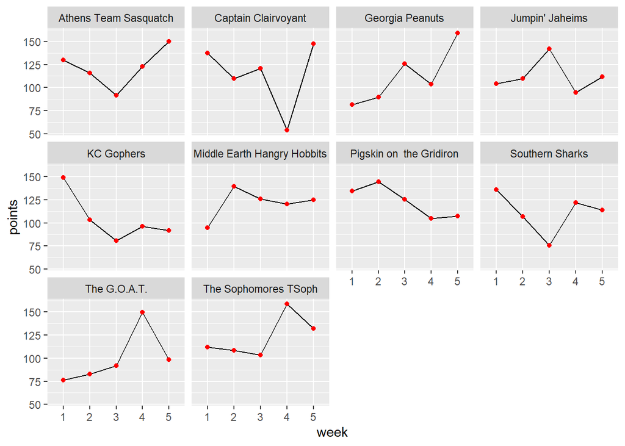

Team Sasquatch and I are both headed up. Brian had a nice rebound week.

### If the season ended today…

Our playoff teams would be Richard, Erin/Trav,Evan, me, and Brian. Our last place finisher would be Jacob.

### Next week’s preview

| Away team | Last 3 wks (away) | Home team | Last 3 wks (home) | Line |
| --- | --- | --- | --- | --- |
| KC Gophers | 268.40 | The G.O.A.T. | 339.72 | The G.O.A.T. (+71.32) |
| Middle Earth Hangry Hobbits | 371.58 | Athens Team Sasquatch | 364.26 | Middle Earth Hangry Hobbits (+7.32) |
| The Sophomores TSoph | 394.02 | Jumpin’ Jaheims | 347.78 | The Sophomores TSoph (+46.24) |
| Southern Sharks | 311.64 | Pigskin on the Gridiron | 337.26 | Pigskin on the Gridiron (+25.62) |
| Georgia Peanuts | 388.49 | Captain Clairvoyant | 321.68 | Georgia Peanuts (+66.81) |

The closest game of the week looks to be the Hobbits and Sasquatch, with a slight edge to Scott’s team. The biggest mismatch pits the GOAT and Gophers, with Jacob heavily favored.

Good luck, y’all!